# lab04

### Machine Learning : Abalone data

## Part 1

Part 1 consist of Abalone data set which contains the information of sea snail such as Gender, Length, Diameter, Height, Whole weight, Shucked weight, Viscera weight, Shell weight and Rings. In this project we will predict the age of the sea snail which is denotes by the Rings. In this project we will perform the following tasks:

1. Loading the data in Jupyter notebook
2. Data cleaning.
3. Data Visualization and checking correlation between attributes.
4. Elimination any two highly correlated values.
5. Spliting the data into 85/15 train and test set.
6. Perfrorm AdaBoostRegressor with different regressors(1-5).
7. Checking the Mean Absolute Error for both the train and the test set.
8. Plotting Mean Absolute Errors using a function by passing arguments.
9. Finding Raw Errors in both the train and test set and comapre them.

## importing libraries

```python
#ALL THE LIBRATIES ARE IMPORTED HERE
#Some additional libraries are also includes which we might not use in this Project
import pandas as pd
import numpy as np
import seaborn as sns
import seaborn as sns; sns.set_theme(color_codes=True)
import matplotlib.pyplot as plt
from sklearn.tree import DecisionTreeClassifier
from sklearn import tree
from sklearn.preprocessing import StandardScaler
from sklearn.model_selection import train_test_split
from sklearn import preprocessing
from sklearn.model_selection import GridSearchCV
from sklearn.tree import export_graphviz
from sklearn.metrics import confusion_matrix,plot_confusion_matrix,precision_score,accuracy_score,classification_report
from sklearn.tree import DecisionTreeRegressor
#REMOVE WARNINGS
import warnings
warnings.filterwarnings('ignore')

from statsmodels.stats.outliers_influence import variance_inflation_factor
# importing one hot encoder from sklearn
from sklearn.preprocessing import OneHotEncoder
from sklearn.svm import SVR,SVC
from sklearn.ensemble import AdaBoostRegressor
#GRAPHS
import matplotlib.pyplot as plt
#FOR FINDING ERRORS
from sklearn.metrics import mean_squared_error,mean_absolute_error
#RANDOM FOREST
from sklearn.ensemble import RandomForestRegressor
```

## Reading file

Reading abalone dataset from the same directory.

```python
data = pd.read_csv("abalone.data")
data.columns = ['Gender','Length','Diameter','Height','Whole weight','Shucked weight','Viscera weight','Shell weight','Rings']

#DATA DESCRIPTION
print("Rows and columns : ",data.shape,"\n")
print(data.info())
print(data.shape)
print("\n--------Statistical information--------")
print(data.describe())
data.head()
```

```
Rows and columns :  (4176, 9)

<class 'pandas.core.frame.DataFrame'>
RangeIndex: 4176 entries, 0 to 4175
Data columns (total 9 columns):
 #   Column          Non-Null Count  Dtype
---  ------          --------------  -----
 0   Gender          4176 non-null   object
 1   Length          4176 non-null   float64
 2   Diameter        4176 non-null   float64
 3   Height          4176 non-null   float64
 4   Whole weight    4176 non-null   float64
 5   Shucked weight  4176 non-null   float64
 6   Viscera weight  4176 non-null   float64
 7   Shell weight    4176 non-null   float64
 8   Rings           4176 non-null   int64
dtypes: float64(7), int64(1), object(1)
memory usage: 293.8+ KB
None
(4176, 9)

--------Statistical information--------
            Length     Diameter       Height  Whole weight  Shucked weight  \
count  4176.000000  4176.000000  4176.000000   4176.000000      4176.00000
mean      0.524009     0.407892     0.139527      0.828818         0.35940
std       0.120103     0.099250     0.041826      0.490424         0.22198
min       0.075000     0.055000     0.000000      0.002000         0.00100
25%       0.450000     0.350000     0.115000      0.441500         0.18600
50%       0.545000     0.425000     0.140000      0.799750         0.33600
75%       0.615000     0.480000     0.165000      1.153250         0.50200
max       0.815000     0.650000     1.130000      2.825500         1.48800

       Viscera weight  Shell weight        Rings
count     4176.000000   4176.000000  4176.000000
mean         0.180613      0.238852     9.932471
std          0.109620      0.139213     3.223601
min          0.000500      0.001500     1.000000
25%          0.093375      0.130000     8.000000
50%          0.171000      0.234000     9.000000
75%          0.253000      0.329000    11.000000
max          0.760000      1.005000    29.000000
```

|  | Gender | Length | Diameter | Height | Whole weight | Shucked weight | Viscera weight | Shell weight | Rings |
| --- | --- | --- | --- | --- | --- | --- | --- | --- | --- |
| 0 | M | 0.350 | 0.265 | 0.090 | 0.2255 | 0.0995 | 0.0485 | 0.070 | 7 |
| 1 | F | 0.530 | 0.420 | 0.135 | 0.6770 | 0.2565 | 0.1415 | 0.210 | 9 |
| 2 | M | 0.440 | 0.365 | 0.125 | 0.5160 | 0.2155 | 0.1140 | 0.155 | 10 |
| 3 | I | 0.330 | 0.255 | 0.080 | 0.2050 | 0.0895 | 0.0395 | 0.055 | 7 |
| 4 | I | 0.425 | 0.300 | 0.095 | 0.3515 | 0.1410 | 0.0775 | 0.120 | 8 |

> We have 9 columns in the dataset and here **Rings is the dependent variable** and rest all are the independent variables.

## Removing Attributes

In order to remove the attributes we will use correlation matrix to see which two values are highly correlated and we will eliminate any one of them from the two which has the lowest correlation with the Rings variable.

|  | Length | Diameter | Height | Whole weight | Shucked weight | Viscera weight | Shell weight | Rings |
| --- | --- | --- | --- | --- | --- | --- | --- | --- |
| Length | 1.000000 | 0.986813 | 0.827552 | 0.925255 | 0.897905 | 0.903010 | 0.897697 | 0.557123 |
| Diameter | 0.986813 | 1.000000 | 0.833705 | 0.925452 | 0.893159 | 0.899726 | 0.905328 | 0.575005 |
| Height | 0.827552 | 0.833705 | 1.000000 | 0.819209 | 0.774957 | 0.798293 | 0.817326 | 0.558109 |
| Whole weight | 0.925255 | 0.925452 | 0.819209 | 1.000000 | 0.969403 | 0.966372 | 0.955351 | 0.540818 |
| Shucked weight | 0.897905 | 0.893159 | 0.774957 | 0.969403 | 1.000000 | 0.931956 | 0.882606 | 0.421256 |
| Viscera weight | 0.903010 | 0.899726 | 0.798293 | 0.966372 | 0.931956 | 1.000000 | 0.907647 | 0.504274 |
| Shell weight | 0.897697 | 0.905328 | 0.817326 | 0.955351 | 0.882606 | 0.907647 | 1.000000 | 0.628031 |
| Rings | 0.557123 | 0.575005 | 0.558109 | 0.540818 | 0.421256 | 0.504274 | 0.628031 | 1.000000 |

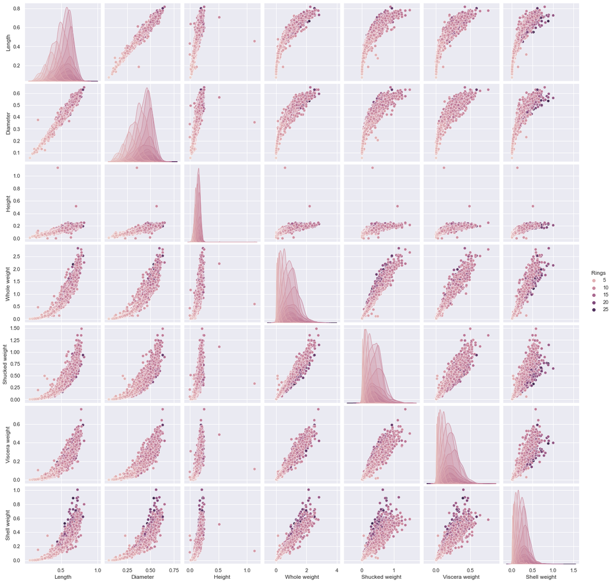

```python
#SHOWS CORRELATION GRAPH USING SEABORNE
sns.set();
sns.pairplot(data, hue='Rings');

#SHOWS CORRELATION BETWEEN ATTRIBUTES
data.corr()
```

> Here **Length and Diameter** are highly correlated which is 0.98, followed by **Whole weight and Shucked weight** which is 0.96. This means Length and Diameter are highly influenced by each other the same way Whole Weight and Shucked Weight are highly influced by each other.  
> We will remove the Length from the dataset and keep the Diameter because the correlation value of Length with Rings compared to the Diameter and Rings is less. The same way we will remove the Shucked Weight because the correlation of Shucked Weight with the Rings is less than the correlation value of the Whole Weight with respective to Rings.

#### Corr Value

```python
#REMOVING ATTRIBUTES, Diameter and Whole Weight
df = data.iloc[:,[0,2,3,4,6,7,8]]
df
```

|  | Gender | Diameter | Height | Whole weight | Viscera weight | Shell weight | Rings |
| --- | --- | --- | --- | --- | --- | --- | --- |
| 0 | M | 0.265 | 0.090 | 0.2255 | 0.0485 | 0.0700 | 7 |
| 1 | F | 0.420 | 0.135 | 0.6770 | 0.1415 | 0.2100 | 9 |
| 2 | M | 0.365 | 0.125 | 0.5160 | 0.1140 | 0.1550 | 10 |
| 3 | I | 0.255 | 0.080 | 0.2050 | 0.0395 | 0.0550 | 7 |
| 4 | I | 0.300 | 0.095 | 0.3515 | 0.0775 | 0.1200 | 8 |
| ... | ... | ... | ... | ... | ... | ... | ... |
| 4171 | F | 0.450 | 0.165 | 0.8870 | 0.2390 | 0.2490 | 11 |
| 4172 | M | 0.440 | 0.135 | 0.9660 | 0.2145 | 0.2605 | 10 |
| 4173 | M | 0.475 | 0.205 | 1.1760 | 0.2875 | 0.3080 | 9 |
| 4174 | F | 0.485 | 0.150 | 1.0945 | 0.2610 | 0.2960 | 10 |
| 4175 | M | 0.555 | 0.195 | 1.9485 | 0.3765 | 0.4950 | 12 |

4176 rows × 7 columns

## Replacing 'M' 'F' values to 'A' (Adult) from gender

Here we will replace the M,F with A in Gender then convert it into numerical values where A=1 and I=0 then perform  
**One-Hot-Encode** inside the same cell.

## One-Hot-Encode

```python
try:
    #REPLACING VALUES
    df['Gender'] = df['Gender'].replace(to_replace =["M", "F"],
                         value ="A")
    print("Categories in gender",df.Gender.unique())

    #CONVERTING INTO NUMERICAL VALUES
    #A=1 and I=0
    #USING get_dummies() TO ACHEIVE ONE-HOTE ENCODING
    df = pd.concat([df.iloc[:,[1,2,3,4,5,6]], pd.get_dummies(df.Gender)],axis=1)
except:
    print("Gender not found in DataFrame.. run the code to read the file")
df
```

```
Categories in gender ['A' 'I']
```

|  | Diameter | Height | Whole weight | Viscera weight | Shell weight | Rings | A | I |
| --- | --- | --- | --- | --- | --- | --- | --- | --- |
| 0 | 0.265 | 0.090 | 0.2255 | 0.0485 | 0.0700 | 7 | 1 | 0 |
| 1 | 0.420 | 0.135 | 0.6770 | 0.1415 | 0.2100 | 9 | 1 | 0 |
| 2 | 0.365 | 0.125 | 0.5160 | 0.1140 | 0.1550 | 10 | 1 | 0 |
| 3 | 0.255 | 0.080 | 0.2050 | 0.0395 | 0.0550 | 7 | 0 | 1 |
| 4 | 0.300 | 0.095 | 0.3515 | 0.0775 | 0.1200 | 8 | 0 | 1 |
| ... | ... | ... | ... | ... | ... | ... | ... | ... |
| 4171 | 0.450 | 0.165 | 0.8870 | 0.2390 | 0.2490 | 11 | 1 | 0 |
| 4172 | 0.440 | 0.135 | 0.9660 | 0.2145 | 0.2605 | 10 | 1 | 0 |
| 4173 | 0.475 | 0.205 | 1.1760 | 0.2875 | 0.3080 | 9 | 1 | 0 |
| 4174 | 0.485 | 0.150 | 1.0945 | 0.2610 | 0.2960 | 10 | 1 | 0 |
| 4175 | 0.555 | 0.195 | 1.9485 | 0.3765 | 0.4950 | 12 | 1 | 0 |

4176 rows × 8 columns

> One-Hot-Encode on the Gender means, we have two values in Gender 'A', 'I' and once we perform One-Hot-Encoding A and I will become two different columns and the values of these two columns will be assigned by binary values with the presence of the category on Gender.  
> We have used **pd.concat([df.iloc[:,[1,2,3,4,5,6]], pd.get_dummies(df.Gender)],axis=1)** to achieve One-hot-encoding.

## Train and Test Split

In the Train-Test split we are using 85% data on the Train set and 15% data for the test set with a random_state of 42. Random_state =42 is provided to avoid getting different values in the train and set test.  
**test_size=0.15** mean 15% of the data has been assigned into test set and rest 85% will automatically be assigned in the train set.

```python
independent_variable = df.iloc[:,[0,1,2,3,4,6,7]]
dependent_variable = df.iloc[:,[5]]
X_train, X_test = train_test_split(independent_variable,test_size=0.15, random_state=42)
Y_train ,Y_test =  train_test_split(dependent_variable,test_size=0.15, random_state=42)

print("X_train",X_train.shape)
print("X_test",X_test.shape)
print("Y_train",Y_train.shape)
print("Y_test",Y_test.shape)
print("X columns :\n", X_train.columns.values)
print("Y columns :\n", Y_train.columns.values)
```

```
X_train (3549, 7)
X_test (627, 7)
Y_train (3549, 1)
Y_test (627, 1)
X columns :
 ['Diameter' 'Height' 'Whole weight' 'Viscera weight' 'Shell weight' 'A'
 'I']
Y columns :
 ['Rings']
```

#### Explanation

> X_train set contains 3549 rows and 7 columns  
> X_test set contains 627 rows and 7 columns  
> Y_train set contains 3549 rows and 1 columns  
> Y_test set contains 627 rows and 1 columns

## AdaBoostRegressor

### Implemantation of SVR

Here we are using AdaBoostRegressor. The signifinance of AdaBoost is that it can make a weak model into a strong one and boosts the models performce because of its adaptive nature hence it redces the chances of errors in the prediction. AdaBoost can be performed in any machine learning algorithm. Here we are using AdaBoostRegressor because we are using Support Vactor Regressor (SVR) and performing Regression operations.  
Hyperparameters: kernal= 'rbf' default  
**n_estimator=5** we are using 5 estimators in our model. the model will generate output for each estimator in our case it is SVR.  
**learning_rate=0.1** it is used for finetuing the model, it shrinks the contribution of each regressor but higher values of learning_rate will reduce the model accuracy.  
**random_state=42** it is used to prevent getting different values every time we run the model.  
**staged_predict** here in AdaBoostRegressor we can not use predict function instead we use staged_predict which predicts Y variable for each easimator and stores it in an array.

```
MAE on TRAIN for Estimator 1  :  [1.59284305]
MAE on TRAIN for Estimator 2  :  [1.59284305]
MAE on TRAIN for Estimator 3  :  [1.57593688]
MAE on TRAIN for Estimator 4  :  [1.57959989]
MAE on TRAIN for Estimator 5  :  [1.57678219]
=============================================
MAE on TEST for Estimator 1  :  [1.62998405]
MAE on TEST for Estimator 2  :  [1.62998405]
MAE on TEST for Estimator 3  :  [1.60127592]
MAE on TEST for Estimator 4  :  [1.60606061]
MAE on TEST for Estimator 5  :  [1.59170654]
```

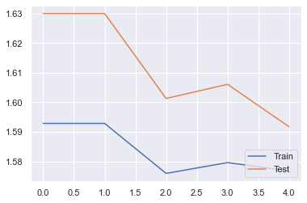

```
===========BEST ESTIMATOR==========
Train : Estimator 3
Test : Estimator 5
```

```python
#SVR
svr = SVR(kernel='rbf')

#AdaBoost
ada_clf = AdaBoostRegressor(svr, n_estimators=5, learning_rate=0.1,random_state=42)

#FITTING
ada_clf.fit(X_train, Y_train)


#PREDICTION
Y_pred_train = ada_clf.staged_predict(X_train)
Y_pred_test = ada_clf.staged_predict(X_test)

#TRAIN AND TEST
Y_PRED_TRAIN = []
Y_PRED_TEST = []


#MEAN ABSOLUTE ERROR
MAE_TRAIN = []
MAE_TEST = []
COUNTER_TRAIN = 0 #FOR ESTIMATORS
COUNTER_TEST = 0 #FOR ESTIMATORS
COUNTER_EST = [1,2,3,4,5] #JUST TO SHOW THE BEST ESTIMATOR

#CONVETED FLOAT VALUES INTO INT BY USING round().astype(int)
for pred_train in Y_pred_train:
    Y_PRED_TRAIN.append(pred_train.round().astype(int))
    COUNTER_TRAIN = COUNTER_TRAIN + 1
    MAE_TRAIN.append(mean_absolute_error(Y_train, pred_train.round().astype(int), multioutput='raw_values'))
    print("MAE on TRAIN for Estimator",COUNTER_TRAIN," : ",mean_absolute_error(Y_train, pred_train.round().astype(int), multioutput='raw_values'))
print("=============================================")
for pred_test in Y_pred_test:
    Y_PRED_TEST.append(pred_test.round().astype(int))
    COUNTER_TEST = COUNTER_TEST + 1
    MAE_TEST.append(mean_absolute_error(Y_test, pred_test.round().astype(int), multioutput='raw_values'))
    print("MAE on TEST for Estimator",COUNTER_TEST," : ",mean_absolute_error(Y_test, pred_test.round().astype(int), multioutput='raw_values'))


#GRAPHICAL REPRESENTATION
plt.plot(MAE_TRAIN)
plt.plot(MAE_TEST)
plt.legend(['Train', 'Test'], loc=4)
plt.show()


#BEST ESTIMATOR IS
print("===========BEST ESTIMATOR==========")
index_est_train = MAE_TRAIN.index(min(MAE_TRAIN))
index_est_test = MAE_TEST.index(min(MAE_TEST))
print("Train : Estimator",COUNTER_EST[index_est_train])
print("Test : Estimator",COUNTER_EST[index_est_test])
```

## Function for True vs Pred values

In this function we pass predicted value and the true value of both the sets (train and test) and the last parameter which is **Project=1** implies project number if it is 1 then the function will show the graphs for the project 1 and to see the graphs in project2 imply Project=2 in the secondhalf of the project.  
**regplot**  
To show the True and the predicted values in both the test and the train set we have used **seaborne regplot** and the **ci=68** will use 68% of the confidence interval corrosponding to the standard error and will draw a regression line on the same plot.

```
========== AVG RAW ERROR =============
Train :  0.4530853761622992
Test :  0.5167464114832536
==========TRUE VS PREDICTED===========
```

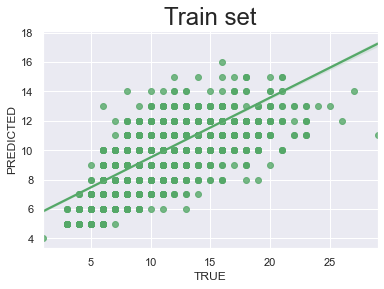

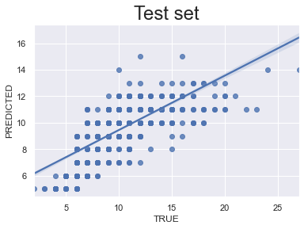

```
============RAW ERRORS==========
```

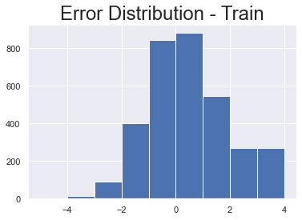

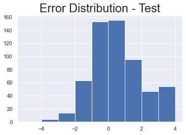

```python
#PRED vs TRUE VALUES
def Train_vs_Test(Y_PRED_TRAIN,Y_PRED_TEST,Y_train,Y_test,Project=1):
    if Project ==1 :
        TRAIN_PRED = Y_PRED_TRAIN[len(Y_PRED_TRAIN) - 1]
        TEST_PRED = Y_PRED_TEST[len(Y_PRED_TEST) - 1]

        TRAIN_TRUE = list(Y_train.iloc[:,0])
        TEST_TRUE = list(Y_test.iloc[:,0])

        RAW_ERR_TRAIN = TRAIN_TRUE - TRAIN_PRED
        RAW_ERR_TEST = TEST_TRUE - TEST_PRED

        print("========== AVG RAW ERROR =============")
        print("Train : ",sum(RAW_ERR_TRAIN) / len(RAW_ERR_TRAIN))
        print("Test : ",sum(RAW_ERR_TEST) / len(RAW_ERR_TEST))

        print("==========TRUE VS PREDICTED===========")
        #CREATING PLOT
        ax = sns.regplot(x=Y_train, y=TRAIN_PRED,ci=68, color="g")
        # Set label for x-axis
        plt.xlabel( "TRUE" , size = 12 )
        # Set label for y-axis
        plt.ylabel( "PREDICTED" , size = 12 )
        # Set title for figure
        plt.title( "Train set" , size = 24 )
        plt.show()

        ax = sns.regplot(x=Y_test, y=TEST_PRED,ci=68, color="b")
        # Set label for x-axis
        plt.xlabel( "TRUE" , size = 12 )
        # Set label for y-axis
        plt.ylabel( "PREDICTED" , size = 12 )
        # Set title for figure
        plt.title( "Test set" , size = 24 )
        plt.show()

        print("============RAW ERRORS==========")
        #HISTOGRAM FOR RAW ERROR TRAIN
        plt.hist(RAW_ERR_TRAIN,bins=range(-5,5))
        plt.title( "Error Distribution - Train" , size = 24 )
        plt.show()

        #HISTOGRAM FOR RAW ERROR TEST
        plt.hist(RAW_ERR_TEST,bins=range(-5,5))
        plt.title( "Error Distribution - Test" , size = 24 )
        plt.show()
    elif Project == 2:
        train_true = list(Y_train.iloc[:,0])
        test_true = list(Y_test.iloc[:,0])

        raw_err_train = train_true - Y_pred_train
        raw_err_test = test_true - Y_pred_test

        print("========== AVG RAW ERROR =============")
        print("Train : ",sum(raw_err_train) / len(raw_err_train))
        print("Test : ",sum(raw_err_test) / len(raw_err_test))


        print("=======TRUE VS PREDICTED========")
        #CREATING PLOT
        ax = sns.regplot(x=Y_train, y=Y_pred_train,ci=68, color="g")
        # Set label for x-axis
        plt.xlabel( "TRUE" , size = 12 )
        # Set label for y-axis
        plt.ylabel( "PREDICTED" , size = 12 )
        # Set title for figure
        plt.title( "Train set" , size = 24 )
        plt.show()

        #STORING RAW ERRORS
        #RAW_ERR_TEST.append(Y_test-INDEX_TEST)
        ax = sns.regplot(x=Y_test, y=Y_pred_test,ci=68, color="b")
        # Set label for x-axis
        plt.xlabel( "TRUE" , size = 12 )
        # Set label for y-axis
        plt.ylabel( "PREDICTED" , size = 12 )
        # Set title for figure
        plt.title( "Test set" , size = 24 )
        plt.show()

        print("=========RAW ERRORS==========")
        #HISTOGRAM FOR RAW ERROR TRAIN
        plt.hist(raw_err_train,bins=range(-5,5))
        plt.title( "Error Distribution - Train" , size = 24 )
        plt.show()

        #HISTOGRAM FOR RAW ERROR TEST
        plt.hist(raw_err_test,bins=range(-5,5))
        plt.title( "Error Distribution - Test" , size = 24 )
        plt.show()



    else:
        print("Please provide either 1 or 2 in Project")
Train_vs_Test(Y_PRED_TRAIN,Y_PRED_TEST,Y_train,Y_test,Project=1)
```

## Part 2

Here we will be analyzing the data of a red wine. In-order to do that we have a dataste called **winequality-red.csv** which contains the information of Red Wine. In this project we will see which are the most important freatures which are required to produce a good quality wine. The dataset contains 12 columns fixed acidity, volatile acidity, citric acid, residual sugar, chlorides, free sulfur dioxide, total sulfur dioxide, density, pH, sulphates, alcohol and quality,the feature **quality** is the dependent variable(Y) rest all are the independent variables (X).  
Our Tasks:

1. Load the data on jupyter notebook.
2. Check for null values.
3. Perform Train-Test split.
4. Perform RandomForestRegressor and find Mean Absolute Errors.
5. Plot True vs Predicted values and Raw Errors using previous function from project 1.
6. Then perform feature importance and again run RandomForestRegressor.
7. Check the Mean Absolute Error after feature importance.
8. Compare both of the MAE before and after.

## Reading file

Readinng the file from the same directory.  
**sep = ";"** is used because the values are separated by ";" in the .csv file. So, the **sep = ";"** is required to split the columns in the dataframe.

```python
data2 = pd.read_csv("winequality-red.csv",sep = ';')
print("Rows and columns : ",data2.shape,"\n")
print(data2.info())
print(data2.shape)
print("\n--------Statistical information--------\n")
print(data2.describe())
data2.head()
```

```
Rows and columns :  (1599, 12)

<class 'pandas.core.frame.DataFrame'>
RangeIndex: 1599 entries, 0 to 1598
Data columns (total 12 columns):
 #   Column                Non-Null Count  Dtype
---  ------                --------------  -----
 0   fixed acidity         1599 non-null   float64
 1   volatile acidity      1599 non-null   float64
 2   citric acid           1599 non-null   float64
 3   residual sugar        1599 non-null   float64
 4   chlorides             1599 non-null   float64
 5   free sulfur dioxide   1599 non-null   float64
 6   total sulfur dioxide  1599 non-null   float64
 7   density               1599 non-null   float64
 8   pH                    1599 non-null   float64
 9   sulphates             1599 non-null   float64
 10  alcohol               1599 non-null   float64
 11  quality               1599 non-null   int64
dtypes: float64(11), int64(1)
memory usage: 150.0 KB
None
(1599, 12)

--------Statistical information--------

       fixed acidity  volatile acidity  citric acid  residual sugar  \
count    1599.000000       1599.000000  1599.000000     1599.000000
mean        8.319637          0.527821     0.270976        2.538806
std         1.741096          0.179060     0.194801        1.409928
min         4.600000          0.120000     0.000000        0.900000
25%         7.100000          0.390000     0.090000        1.900000
50%         7.900000          0.520000     0.260000        2.200000
75%         9.200000          0.640000     0.420000        2.600000
max        15.900000          1.580000     1.000000       15.500000

         chlorides  free sulfur dioxide  total sulfur dioxide      density  \
count  1599.000000          1599.000000           1599.000000  1599.000000
mean      0.087467            15.874922             46.467792     0.996747
std       0.047065            10.460157             32.895324     0.001887
min       0.012000             1.000000              6.000000     0.990070
25%       0.070000             7.000000             22.000000     0.995600
50%       0.079000            14.000000             38.000000     0.996750
75%       0.090000            21.000000             62.000000     0.997835
max       0.611000            72.000000            289.000000     1.003690

                pH    sulphates      alcohol      quality
count  1599.000000  1599.000000  1599.000000  1599.000000
mean      3.311113     0.658149    10.422983     5.636023
std       0.154386     0.169507     1.065668     0.807569
min       2.740000     0.330000     8.400000     3.000000
25%       3.210000     0.550000     9.500000     5.000000
50%       3.310000     0.620000    10.200000     6.000000
75%       3.400000     0.730000    11.100000     6.000000
max       4.010000     2.000000    14.900000     8.000000
```

|  | fixed acidity | volatile acidity | citric acid | residual sugar | chlorides | free sulfur dioxide | total sulfur dioxide | density | pH | sulphates | alcohol | quality |
| --- | --- | --- | --- | --- | --- | --- | --- | --- | --- | --- | --- | --- |
| 0 | 7.4 | 0.70 | 0.00 | 1.9 | 0.076 | 11.0 | 34.0 | 0.9978 | 3.51 | 0.56 | 9.4 | 5 |
| 1 | 7.8 | 0.88 | 0.00 | 2.6 | 0.098 | 25.0 | 67.0 | 0.9968 | 3.20 | 0.68 | 9.8 | 5 |
| 2 | 7.8 | 0.76 | 0.04 | 2.3 | 0.092 | 15.0 | 54.0 | 0.9970 | 3.26 | 0.65 | 9.8 | 5 |
| 3 | 11.2 | 0.28 | 0.56 | 1.9 | 0.075 | 17.0 | 60.0 | 0.9980 | 3.16 | 0.58 | 9.8 | 6 |
| 4 | 7.4 | 0.70 | 0.00 | 1.9 | 0.076 | 11.0 | 34.0 | 0.9978 | 3.51 | 0.56 | 9.4 | 5 |

## Checking null values

```python
data2.isnull().sum()
```

```
fixed acidity           0
volatile acidity        0
citric acid             0
residual sugar          0
chlorides               0
free sulfur dioxide     0
total sulfur dioxide    0
density                 0
pH                      0
sulphates               0
alcohol                 0
quality                 0
dtype: int64
```

> No null values in the dataset

## Train-Test split

In the Train-Test split we are using 85% data on the Train set and 15% data for the test set with a random_state of 42. **Random_state =42** is provided to avoid getting different values in the train and set test.  
**test_size=0.15** mean 15% of the data has been assigned into test set and rest 85% will automatically be assigned in the train set.

```python
independent_variable = data2.iloc[:,[0,1,2,3,4,5,6,7,8,9,10]]
dependent_variable = data2.iloc[:,[11]]
X_train, X_test =  train_test_split(independent_variable,test_size=0.15, random_state=42)
Y_train ,Y_test =  train_test_split(dependent_variable,test_size=0.15, random_state=42)

print("X_train",X_train.shape)
print("X_test",X_test.shape)
print("Y_train",Y_train.shape)
print("Y_test",Y_test.shape)
print("X columns : ", X_train.columns.values)
print("Y columns : ", Y_train.columns.values)
```

```
X_train (1359, 11)
X_test (240, 11)
Y_train (1359, 1)
Y_test (240, 1)
X columns :  ['fixed acidity' 'volatile acidity' 'citric acid' 'residual sugar'
 'chlorides' 'free sulfur dioxide' 'total sulfur dioxide' 'density' 'pH'
 'sulphates' 'alcohol']
Y columns :  ['quality']
```

#### Explanation

> X_train set contains 1359 rows and 11 columns  
> X_test set contains 240 rows and 11 columns  
> Y_train set contains 1359 rows and 1 columns  
> Y_test set contains 240 rows and 1 columns

## RandomForestRegressor

RandomForestRegressor comes from Random Forest which an ensemble method. RandomForestRegressor can use multiple decision tree using bagging to generate the best predicted value. In our case RandomForestRegressor will be averaging the result of each tree to improve the predicted value and control the over-fitting.  
**We will be using 100 trees in our model**  
Also we will find out the scenario when the algorithm can overfit our model. The code which overfits the model will be pasted in the **Markdown cell.**  
**Hyperparameters**:  
**n_estimators=100 :** Number of estimators, passes 100 trees in our model.  
**max_depth = 5 :** Used to generate the number of nodes.  
**random_state=42 :** Random Forest takes sample values randomly so everytime we run our model we might get different results. So random_state=42 prevents getting different values every time we run the model.  
**Mean Absolute Error**  
We have used mean_absolute_error() to get the MAE value where **multioutput='raw_values'** returns all the errors if we have any multioutput input.

```python
#CLASSIFIER
regr = RandomForestRegressor(n_estimators=100,max_depth=5, random_state=42)

################################################################
#CODE FOR OVERFITTING THE MODEL
#regr = RandomForestRegressor(n_estimators=100,max_depth=5, random_state=0)
################################################################


#FITTING
regr.fit(X_train, Y_train)


#PREDICTING
Y_pred_train = regr.predict(X_train).round().astype(int) #CONVERTING INTO INTEGER
Y_pred_test =  regr.predict(X_test).round().astype(int)


#MAE
MAE_BEFORE_FI_TRAIN = mean_absolute_error(Y_train,Y_pred_train, multioutput='raw_values')
MAE_BEFORE_FI_TEST = mean_absolute_error(Y_test,Y_pred_test, multioutput='raw_values')
print("MAE on TRAIN SET :",MAE_BEFORE_FI_TRAIN)
print("MAE on TEST SET :",MAE_BEFORE_FI_TEST)
```

```
MAE on TRAIN SET : [0.3451067]
MAE on TEST SET : [0.48333333]
```

#### Explanations

> **Overfitting**  
> Overfitting is something where the predicted values on training data is too well which can negetively impact the model for new data. Overfitting will reducre the error rate on the training set but still the error on the test set for the same model wont effect much.  
> **Code for overfitting**  
> regr = RandomForestRegressor(n_estimators=100,max_depth=100, random_state=0) **Result** MAE on TRAIN SET : [0.04635762]  
> MAE on TEST SET : [0.38333333]

### Function call for Graph from Project 1

Train_vs_Test() is called to show the error dictribution in Train and Test set from **Project 1**

```
========== AVG RAW ERROR =============
Train :  0.06254598969830757
Test :  0.13333333333333333
=======TRUE VS PREDICTED========
```

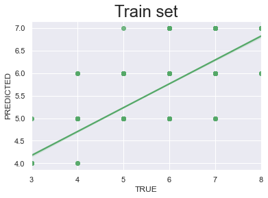

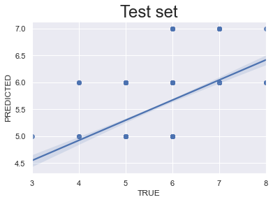

```
=========RAW ERRORS==========
```

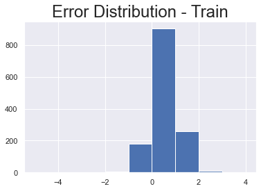

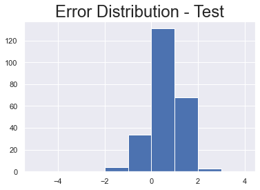

```python
Train_vs_Test(Y_pred_train,Y_pred_test,Y_train,Y_test,Project=2)
```

> **Graph TRUE vs PRED**  
> We have used **regplot** to show the True Y and the Predicted Y values. Our code takes 68% of the confidence interval corrosponding to standard error and also it create a liner model into the graph. The **shaded part** accross the liner model depicts, if we have more error rates then we will have a wider shaded region. But here we have observed from both the graphs espicially on the train set, the shaded region is almost negligible because our MAE on the train set does not change much for each estimators. The same way we can observe a slight shaded region accross the liner model which denotes that the error rate in the test set is higher than the training set.  
> **RAW ERROS**  
> We found the **raw errors** by subtracting the predicted value(Y) from the ground truth value(Y). We used the predicted value of the last estimator output because last estimator output will have the best predicted result.  
> The first histogrm shows the Raw Erros of the training set and in the second histogram we have observed Raw Errors of the test set. From both the visualization we can observe that our model is a very model as it produced highest number of 0 values after subtracting the predicted value from the true value which means our model has correctly predicted the values for the X_train and X_test input variables.

## Feature Importance

For feature importance we are using **feature_importances_** and will see which features are playing the most significant role to imporove the wine quality.  
**Features with highest Feature Importance value would be the most important feature which drives the quality of the wine.**  
**Condition :**  
We will remove all the features having Feature Importance value less than 5% (0.05) and at last we will calculate the total Feature Importance Score.

```python
#CREATING VARIABLES TO STORE NAMES
feature_name,feature_score=[],[]


#SELECTING IMPORTANT FEATURES
for name,score in zip(X_train.columns,rnd_clf.feature_importances_):
    score = round(score,2) * 100; #JUST ROUNDING OFF THE SCORE TILL 2 DECIMAL VALUES & CONVERTING IT TO PERCENTAGE
    if score < 5 :
        print("LESS IMPORTANT : ",name," ==== ",score,"%")
    else:
        feature_name.append(name)
        feature_score.append(score)
        print("IMPORTANT : ",name," ==== ",score,"%")


#PRINTING OUT IMP FEATURES
print("\n===============================")
print("=========IMP FEATURES==========")
print("===============================")
for i in range(0,len(feature_name)):
    print(feature_name[i]," : ",feature_score[i],"%")
print("\nTotal Feature Importance score is : ",sum(feature_score))
```

```
LESS IMPORTANT :  fixed acidity  ====  3.0 %
IMPORTANT :  volatile acidity  ====  12.0 %
LESS IMPORTANT :  citric acid  ====  2.0 %
LESS IMPORTANT :  residual sugar  ====  3.0 %
LESS IMPORTANT :  chlorides  ====  3.0 %
LESS IMPORTANT :  free sulfur dioxide  ====  2.0 %
IMPORTANT :  total sulfur dioxide  ====  6.0 %
LESS IMPORTANT :  density  ====  2.0 %
LESS IMPORTANT :  pH  ====  2.0 %
IMPORTANT :  sulphates  ====  21.0 %
IMPORTANT :  alcohol  ====  44.0 %

===============================
=========IMP FEATURES==========
===============================
volatile acidity  :  12.0 %
total sulfur dioxide  :  6.0 %
sulphates  :  21.0 %
alcohol  :  44.0 %

Total Feature Importance score is :  83.0
```

#### Explaination

> **Feature selection**  
> Now we will select our features having **Feature Importance Score more than 5%**  
> and we can see features having score grater than 5% are  
> volatile acidity : 12.0 %  
> total sulfur dioxide : 6.0 %  
> sulphates : 21.0 %  
> alcohol : 44.0 %  
> And among all alcohol is the one hvaing highest Feature Imporatnce score and the total score is 83.

## Train-Test split

Already we have train and set set so we just need to choose the IMP Features from them which are volatile acidity, total sulfur dioxide, sulphates and alcohol. To make the train and test set using these variables we will simply use the index of all these attributes from the main dataset that is why we are just passing the names.  
**feature_name** : ['volatile acidity', 'total sulfur dioxide', 'sulphates', 'alcohol']

```python
#FEATURE SELECTION
X_train = X_train[feature_name]
X_test = X_test[feature_name]

print("X_train",X_train.shape)
print("X_test",X_test.shape)
print("Y_train",Y_train.shape)
print("Y_test",Y_test.shape)
print("X columns : ", X_train.columns.values)
print("Y columns : ", Y_train.columns.values)
```

```
X_train (1359, 4)
X_test (240, 4)
Y_train (1359, 1)
Y_test (240, 1)
X columns :  ['volatile acidity' 'total sulfur dioxide' 'sulphates' 'alcohol']
Y columns :  ['quality']
```

### RandomForestRegressor - FI

Now we are using RandomForestRegressor with the same hyperparameter as done previously before Feature Importance but this time we are running the model after feature selection.  
**round().astype(int) :** is used to convert the predicted results into integer values.

```python
#CLASSIFIER
regr = RandomForestRegressor(n_estimators=100, max_depth=5, random_state=42)


#FITTING
regr.fit(X_train, Y_train)


#PREDICTING
Y_pred_train = regr.predict(X_train).round().astype(int) #CONVERTING INTO INTEGER
Y_pred_test =  regr.predict(X_test).round().astype(int)


#MAE
MAE_AFTER_FI_TRAIN = mean_absolute_error(Y_train,Y_pred_train, multioutput='raw_values')
MAE_AFTER_FI_TEST = mean_absolute_error(Y_test,Y_pred_test, multioutput='raw_values')
print("MAE on TRAIN SET :",MAE_AFTER_FI_TRAIN)
print("MAE on TEST SET :",MAE_AFTER_FI_TEST)
```

```
MAE on TRAIN SET : [0.34952171]
MAE on TEST SET : [0.48333333]
```

#### Explainations

> The Mean Absolute Error on the Train and test set is stored in MAE_AFTER_FI_TRAIN and MAE_AFTER_FI_TEST respectively. For the training set the MAE is lower than the test set and it is less than 1 which depicts our models to be a good estimatior for this project.

## Comparision

We will compare the Mean Absolute Error (MAE) observed before Feature Importance and after the feature imporamce score.  
And we will also see the difference by subtracting the MAEs of both the sets (Train and Test) to know how much it diviates after the feature selection.

```python
print("===============BEFORE=================")
print("MAE on TRAIN SET :",MAE_BEFORE_FI_TRAIN)
print("MAE on TEST SET :",MAE_BEFORE_FI_TEST)
print("===============AFTER=================")
print("MAE on TRAIN SET :",MAE_AFTER_FI_TRAIN)
print("MAE on TEST SET :",MAE_AFTER_FI_TEST)
print("=============Difference===============")
print("TRAIN SET :",abs(MAE_BEFORE_FI_TRAIN - MAE_AFTER_FI_TRAIN))
print("TEST SET :",abs(MAE_BEFORE_FI_TEST - MAE_AFTER_FI_TEST))
```

```
===============BEFORE=================
MAE on TRAIN SET : [0.3451067]
MAE on TEST SET : [0.48333333]
===============AFTER=================
MAE on TRAIN SET : [0.34952171]
MAE on TEST SET : [0.48333333]
=============Difference===============
TRAIN SET : [0.00441501]
TEST SET : [0.]
```

#### Explainations

> The Mean Absolute Error without removing any feature on the Train set is 0.3451067 and on the Test set the value is 0.48333333  
> After feature selection the Mean Absolute Error on the Train set is 0.34952171 and on the Test set it is 0.48333333.  
> So the difference on the train set is 0.00441501 (which can be ignored) and on the test set it is 0 (did not change).  
> **Observation**  
> From the above, we can see after removing the features(17% Feature importance score) we are still getting almost the same result(Same MAE values). So we can conclude that the feature having Feature Importance Score less than 5% is not required in the model beacuse anyways we are getting almost the same result in both the sets (test & train) which will also reduce the complexity of the models by eliminating columns which are not required.